# Residuals, Sums of Squares, and R-Squared

```r
library(tidyverse)
library(pander)
library(mosaic)
library(readr)

weather <- read.csv("C:/Users/gkrud/OneDrive/바탕 화면/2024 Spring/Math 425/Statistics-Notebook-master/NEW ANALYSES/W01/DATA/Weather.csv", header=TRUE)
```

## Residual

```r
# Fit a linear model
model <- lm(Temp ~ Wind, data = weather)
summary(model) %>% pander()
```

|  | Estimate | Std. Error | t value | Pr(>\|t\|) |
| --- | --- | --- | --- | --- |
| **(Intercept)** | 47.85 | 4.341 | 11.02 | 3.639e-09 |
| **Wind** | 0.3509 | 0.3966 | 0.8847 | 0.3887 |

Fitting linear model: Temp ~ Wind

| Observations | Residual Std. Error | $R^2$ | Adjusted $R^2$ |
| --- | --- | --- | --- |
| 19 | 6.322 | 0.04401 | -0.01222 |

[figure not shown]

```r
# Plot with residuals
ggplot(weather,aes(x= Wind, y = Temp))+
  geom_point() +
  geom_smooth(method = "lm", formula = y~x, se= FALSE) +
  labs(title = "Relationship between Day and Temperature in Rexburg, ID April 2024",
       x = "Day",
       y = "Temperature (°F)")
```

#### What is a residual?

The residual ($e_i$) is calculated as the vertical difference between the observed temperature ($y_i$) and the predicted temperature ( $\hat{y_i}$).

The residual ($e_i$) is calculated as:

$$e_i = y_i - \hat{y_i}$$
Residual = Observed value − Predicted value

#### Uses of a Residual in Regression Analysis:

1. Model Accuracy: Residuals help assess the accuracy of a regression model. Small residuals indicate that the model predictions are close to the actual data, suggesting a good fit. Conversely, large residuals suggest a poor fit.
2. Identifying Outliers: Large residuals can indicate outliers or anomalies in the data that may not follow the same trend as the rest of the data set.
3. Model Improvement: Analyzing the pattern of residuals can help diagnose issues with the model, such as non-linearity, heteroscedasticity (non-constant variance), or other influences not accounted for by the model. This analysis can lead to model refinements.

#### What Does a Residual Tell Us About the Predicted Temperature for Monday?

If you have a residual for the predicted temperature on Monday, it tells you how off the prediction was for that specific day. For example:

- Positive Residual: If the residual is positive, it means the actual temperature was higher than what the model predicted for Monday. This might suggest underestimation by the model on that day.
- Negative Residual: Conversely, a negative residual indicates that the actual temperature was lower than the predicted temperature, suggesting overestimation by the model.

## SSE, SSR, SSTO

#### SSE (Sum of Squared Errors)

- Formula:
  $$\sum (Y - \hat{Y})^2$$
- Explanation: SSE measures the total deviation of the response values from the fitted values. It reflects the unexplained variance by the model.

#### SSR (Sum of Squares due to Regression)

- Formula:
  $$\sum (\hat{Y} - \overline{Y})^2$$
- Explanation: SSR measures how much of the total variation in the dependent variable is explained by the independent variable(s) in the model.

#### SSTO (Total Sum of Squares)

- Formula:
  $$\sum (Y - \overline{Y})^2$$
- Explanation: SSTO is the total variance in the response variable. It is the sum of the squared differences between the observed values and the mean of the observed values.

#### Relationships and Differences:

- Relationship: These metrics are related through the equation: $SSTO = SSE + SSR$
- Differences: SSTO represents the total variability around the mean, SSR represents the part of the variability that is explained by the regression model, and SSE represents the part of the variability that the model fails to explain.

#### Use in Regression Analysis

Relative Magnitudes: Smallest: All values can theoretically be zero, but in practice, they are usually positive.

Largest: SSTO is always the largest, followed by either SSE or SSR.

Desired Size: Smaller SSE: Indicates better fit as it means less unexplained variability.

Larger SSR: Indicates that more variability is explained by the model.

Larger R-squared (SSR/SSTO): Indicates a better fit overall.

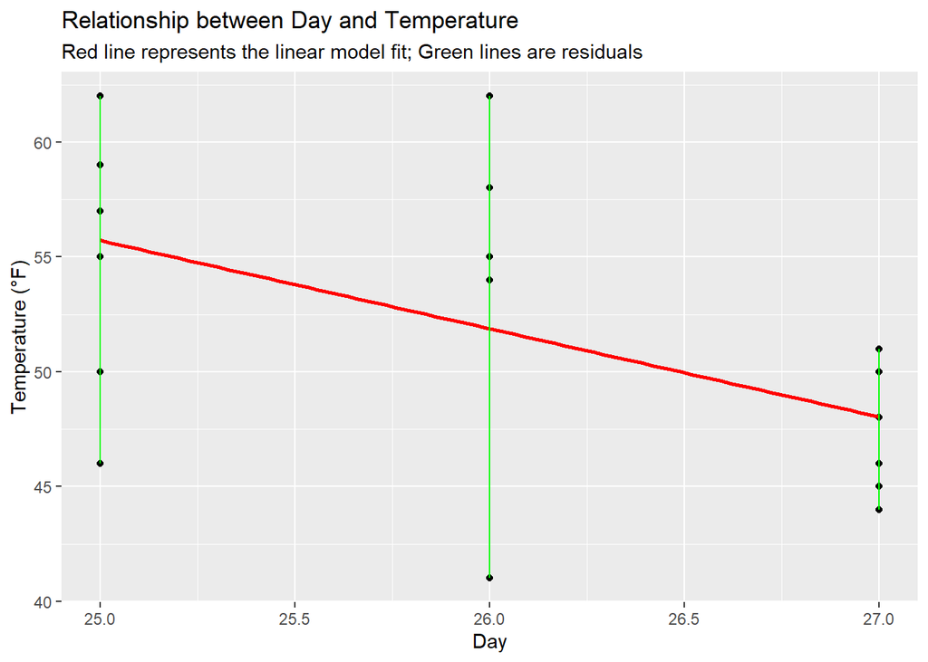

```r
# Assuming you have a dataset 'weather_data' with columns 'Day' and 'Temp'
# and you have fitted a model like so:
model <- lm(Temp ~ Day, data = weather)

# Create a plot using ggplot
ggplot(weather, aes(x = Day, y = Temp)) +
  geom_point() +  # Plot the original data points
  geom_smooth(method = "lm", se = FALSE, color = "red") +  # Add the regression line
  geom_segment(aes(xend = Day, yend = model$fitted.values), color = "green") +  # Add residuals
  labs(title = "Relationship between Day and Temperature",
       subtitle = "Red line represents the linear model fit; Green lines are residuals",
       x = "Day",
       y = "Temperature (°F)")
```

## R-squared

#### What is R-squared?

Definition: R-squared is “The proportion of variability in Y that can be explained by the regression.” This statistical measure represents how well the variability of the dependent variable ($Y$) is accounted for by the independent variables in the regression model.

#### Key Terms in the Definition

- Proportion: This indicates a fraction or percentage of the total. In the context of R-squared, it refers to the part of the total variation in $Y$ that can be attributed to the variation in the independent variables.
- Variability: This refers to how spread out the values of $Y$ are. It’s a measure of the dispersion or how much the values differ from the mean ($\bar{Y}$).
- Explained: In regression, “explained” variability is the part that the model successfully predicts or accounts for, based on the relationships identified between $Y$ and the independent variables.

#### Calculation of R-squared

R-squared is calculated using the formula:

$$R^2 = \frac{\text{SSR}}{\text{SSTO}} = \frac{\sum (\hat{Y}_i -
\overline{Y})^2}{\sum (Y_i - \overline{Y})^2}$$
Where:

- SSR (Sum of Squares due to Regression) measures the explained variation.
- SSTO (Total Sum of Squares) measures the total variation in $Y$.

#### Interpretation of R-squared

- Value Range: R-squared ranges from 0 to 1. A value of 0 means that the regression does not explain any of the variability in the dependent variable. A value of 1 indicates that the regression perfectly explains the variability.
- Usage: A higher R-squared value indicates a better model fit. However, it does not indicate whether the regression model is appropriate or the predictors are relevant; it simply measures how much of the variability in $Y$ is explained by the model.

#### Differences from the P-value of the Slope

- R-squared tells you the proportion of variance explained by the model. It’s a measure of fit quality and does not perform any hypothesis tests.
- P-value of the slope tests the hypothesis that the slope is zero (no effect). A low p-value (typically <0.05) indicates that we can reject the null hypothesis of zero slope, confirming the predictor’s statistical significance in the model.

#### Visualizing R-squared

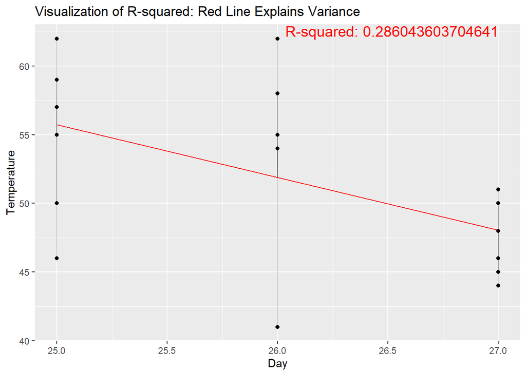

```r
data <- data.frame(
  Day = weather$Day,
  Temp = weather$Temp,
  Fitted = predict(model)
)

ggplot(data, aes(x = Day, y = Temp)) +
  geom_point() +
  geom_line(aes(y = Fitted), color = "red") +
  geom_segment(aes(xend = Day, yend = Fitted), alpha = 0.2) +
  labs(title = "Visualization of R-squared: Red Line Explains Variance",
       x = "Day",
       y = "Temperature") +
  annotate("text", x = Inf, y = Inf, label = paste("R-squared:", summary(model)$r.squared),
           hjust = 1.1, vjust = 1.1, size = 5, color = "red")
```

Points: Each point represents an observed value of $Y$.

Red Line: Represents the fitted values $\hat{Y}$ from the regression.

Vertical Lines: The distance between the points and the red line represents the residuals. The shorter these lines, the higher the R-squared and better the model explains the data.

## MSE & “Residual Standard Error”

#### What is MSE?

“MSE” stands for Mean Squared Error. It’s a measure used in statistical modeling, particularly in regression analysis, to quantify the average of the squares of the errors—that is, the average squared difference between the estimated values and the actual value.

#### Calculation and Range of MSE

- Calculation: MSE is calculated as the sum of the squares of the residuals divided by the number of observations:

$$\text{MSE} = \frac{1}{n} \sum (Y_i - \hat{Y}_i)^2$$

where $Y_i$ are the actual observations, $\hat{Y_i}$ are the predicted values, and $n$ is the number of observations.

- Range:

Minimum: MSE can be as low as 0, which would mean that the model predictions perfectly match the actual data (though this is rare in practice).

Maximum: There’s no upper limit to the MSE, as it depends on the data. If the model predictions are very far from the actual data, the MSE can be very high.

#### Relationship and Differences from R-squared

- MSE vs. R-squared: While MSE measures the average squared error of the model, R-squared measures the proportion of variance in the dependent variable that is predictable from the independent variables. They are related but measure different aspects of model performance.
- Relationship: There isn’t a direct formula linking MSE and R-squared, but both are derived from the residuals of the model. A lower MSE generally indicates a model that would also yield a higher R-squared, showing better fit and prediction accuracy.

#### Comparison with Residual Standard Error

- Residual Standard Error (RSE) is another measure of the spread of these residuals. It is the square root of the MSE when calculated as the sum of squared residuals divided by the degrees of freedom (usually $n−2$ for linear regression with two parameters)

$$\text{RSE} = \sqrt{\frac{1}{n-2} \sum (Y_i - \hat{Y}_i)^2}$$

- RSE in Regression Summary: In R, the RSE can be found in the regression summary output as “Residual standard error.”

#### Desired Size for MSE and RSE

Preference: Both MSE and RSE should ideally be as small as possible. Lower values indicate that the model predictions are closer to the actual data, suggesting a better fit.

#### Units of Measurement

- MSE and RSE Units: Both are expressed in the units of the dependent variable squared for MSE and the units of the dependent variable for RSE. For example, if your dependent variable is measured in degrees Fahrenheit, MSE will be in square degrees Fahrenheit($°F^2$), and RSE will be in degrees Fahrenheit($°F$). R-squared Units: Unlike MSE and RSE, R-squared is unitless. It is a proportion and therefore expressed as a number between 0 and 1, reflecting a percentage of variance explained by the model without any reference to the units of the data.

#### Summary

Understanding these metrics — MSE, RSE, and R-squared—and their interrelationships helps in assessing model performance comprehensively. Their measurements and implications are crucial for refining models and achieving better predictions.